# KaanErtan_HW1_HTML

```python
import matplotlib.pyplot as plt
import pandas as pd

file_path = 'C:/Users/Kaan Ertan/Desktop/ie360-hw1/House-Sales-Statistics.xlsx'

house_sales = pd.read_excel(file_path, sheet_name='EVDS')
print(house_sales.index[:5])
```

```
RangeIndex(start=0, stop=5, step=1)
```

## Series Data Selection

#### In order to find data which meet the criteria, I tried the following data:

1- House Sale Statistics

2- USD Rates

3- Short-Term External Debt Stock (Million USD)

4- Gold Production of Mining Companies Declaration (Kg)

As a result, Short-Term External Debt Stock (Million USD) showed correlation with other data but the other 3 metrics were correlated less than 0.5 pairwise. So I will be analyzing these 3 datasets.

### House Sales Statistics

```python
house_sales
```

|  | Date | TP AKONUTSAT1 TOPLAM | Unnamed: 2 |
| --- | --- | --- | --- |
| 0 | 2021-01 | 70587 | NaN |
| 1 | 2021-02 | 81222 | NaN |
| 2 | 2021-03 | 111241 | NaN |
| 3 | 2021-04 | 95863 | NaN |
| 4 | 2021-05 | 59166 | NaN |
| 5 | 2021-06 | 134731 | NaN |
| 6 | 2021-07 | 107785 | NaN |
| 7 | 2021-08 | 141400 | NaN |
| 8 | 2021-09 | 147143 | NaN |
| 9 | 2021-10 | 137401 | NaN |
| 10 | 2021-11 | 178814 | NaN |
| 11 | 2021-12 | 226503 | NaN |
| 12 | 2022-01 | 88306 | NaN |
| 13 | 2022-02 | 97587 | NaN |
| 14 | 2022-03 | 134170 | NaN |
| 15 | 2022-04 | 133058 | NaN |
| 16 | 2022-05 | 122768 | NaN |
| 17 | 2022-06 | 150509 | NaN |
| 18 | 2022-07 | 93902 | NaN |
| 19 | 2022-08 | 123491 | NaN |
| 20 | 2022-09 | 113402 | NaN |
| 21 | 2022-10 | 102660 | NaN |
| 22 | 2022-11 | 117806 | NaN |
| 23 | 2022-12 | 207963 | NaN |
| 24 | 2023-01 | 97708 | NaN |
| 25 | 2023-02 | 80031 | NaN |
| 26 | 2023-03 | 105476 | NaN |
| 27 | 2023-04 | 85652 | NaN |
| 28 | 2023-05 | 113276 | NaN |
| 29 | 2023-06 | 83636 | NaN |
| 30 | 2023-07 | 109548 | NaN |
| 31 | 2023-08 | 122091 | NaN |
| 32 | 2023-09 | 102656 | NaN |
| 33 | 2023-10 | 93761 | NaN |
| 34 | 2023-11 | 93514 | NaN |
| 35 | 2023-12 | 138577 | NaN |
| 36 | 2024-01 | 80308 | NaN |
| 37 | NaN | NaN | NaN |
| 38 | NaN | NaN | NaN |
| 39 | Series Descriptions | NaN | NaN |
| 40 | TP.AKONUTSAT1.TOPLAM | House Sales Statistics _ Turkey _ Total sales(... | Observation: Cumulative |
| 41 | NaN | NaN | NaN |
| 42 | Notes | NaN | NaN |
| 43 | TP.AKONUTSAT1.TOPLAM | Methodological Changes | https://data.tuik.gov.tr/Search/Search?text=Co... |
| 44 | NaN | Datasource | TURKSTAT |
| 45 | NaN | Metadata Link | https://data.tuik.gov.tr/Search/Search?text=Co... |
| 46 | NaN | Revision Policy | https://data.tuik.gov.tr/Search/Search?text=Co... |
| 47 | NaN | Tags | House, Sales Statistics |

```python
house_sales=house_sales.drop(columns=['Unnamed: 2'])
```

```python
len(house_sales)
```

```
48
```

```python
house_sales = house_sales.iloc[:37]
```

```python
house_sales
```

|  | Date | TP AKONUTSAT1 TOPLAM |
| --- | --- | --- |
| 0 | 2021-01 | 70587 |
| 1 | 2021-02 | 81222 |
| 2 | 2021-03 | 111241 |
| 3 | 2021-04 | 95863 |
| 4 | 2021-05 | 59166 |
| 5 | 2021-06 | 134731 |
| 6 | 2021-07 | 107785 |
| 7 | 2021-08 | 141400 |
| 8 | 2021-09 | 147143 |
| 9 | 2021-10 | 137401 |
| 10 | 2021-11 | 178814 |
| 11 | 2021-12 | 226503 |
| 12 | 2022-01 | 88306 |
| 13 | 2022-02 | 97587 |
| 14 | 2022-03 | 134170 |
| 15 | 2022-04 | 133058 |
| 16 | 2022-05 | 122768 |
| 17 | 2022-06 | 150509 |
| 18 | 2022-07 | 93902 |
| 19 | 2022-08 | 123491 |
| 20 | 2022-09 | 113402 |
| 21 | 2022-10 | 102660 |
| 22 | 2022-11 | 117806 |
| 23 | 2022-12 | 207963 |
| 24 | 2023-01 | 97708 |
| 25 | 2023-02 | 80031 |
| 26 | 2023-03 | 105476 |
| 27 | 2023-04 | 85652 |
| 28 | 2023-05 | 113276 |
| 29 | 2023-06 | 83636 |
| 30 | 2023-07 | 109548 |
| 31 | 2023-08 | 122091 |
| 32 | 2023-09 | 102656 |
| 33 | 2023-10 | 93761 |
| 34 | 2023-11 | 93514 |
| 35 | 2023-12 | 138577 |
| 36 | 2024-01 | 80308 |

```python
house_sales.columns = ['Date', 'House Sales']
house_sales['Date'] = pd.to_datetime(house_sales['Date'])
house_sales.set_index('Date', inplace=True)
```

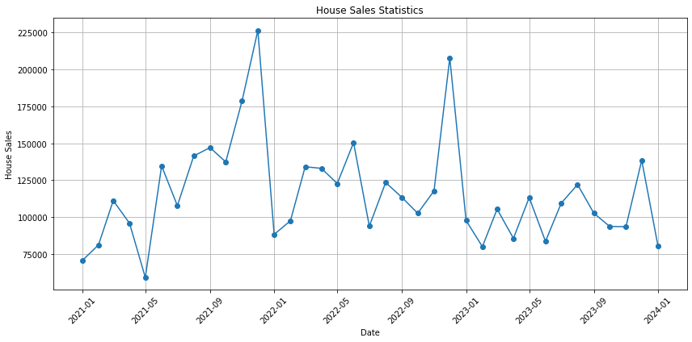

```python
plt.figure(figsize=(12, 6))
plt.plot(house_sales.index, house_sales['House Sales'], marker='o')
plt.title('House Sales Statistics')
plt.xlabel('Date')
plt.ylabel('House Sales')
plt.grid(True)
plt.xticks(rotation=45)
plt.tight_layout()

# Display the plot
plt.show()
```

### USD Rates

```python
file_path = 'C:/Users/Kaan Ertan/Desktop/ie360-hw1/USD-buyer.xlsx'

usd_rates = pd.read_excel(file_path, sheet_name='EVDS')
```

```python
usd_rates
```

|  | Date | TP DK USD A YTL | Unnamed: 2 |
| --- | --- | --- | --- |
| 0 | 2021-01 | 7.393975 | NaN |
| 1 | 2021-02 | 7.072365 | NaN |
| 2 | 2021-03 | 7.628235 | NaN |
| 3 | 2021-04 | 8.155024 | NaN |
| 4 | 2021-05 | 8.34225 | NaN |
| 5 | 2021-06 | 8.596682 | NaN |
| 6 | 2021-07 | 8.612941 | NaN |
| 7 | 2021-08 | 8.475714 | NaN |
| 8 | 2021-09 | 8.511882 | NaN |
| 9 | 2021-10 | 9.139945 | NaN |
| 10 | 2021-11 | 10.523264 | NaN |
| 11 | 2021-12 | 13.528496 | NaN |
| 12 | 2022-01 | 13.519262 | NaN |
| 13 | 2022-02 | 13.621125 | NaN |
| 14 | 2022-03 | 14.565609 | NaN |
| 15 | 2022-04 | 14.683567 | NaN |
| 16 | 2022-05 | 15.623922 | NaN |
| 17 | 2022-06 | 16.964718 | NaN |
| 18 | 2022-07 | 17.387417 | NaN |
| 19 | 2022-08 | 17.99495 | NaN |
| 20 | 2022-09 | 18.281477 | NaN |
| 21 | 2022-10 | 18.564614 | NaN |
| 22 | 2022-11 | 18.590895 | NaN |
| 23 | 2022-12 | 18.636968 | NaN |
| 24 | 2023-01 | 18.757573 | NaN |
| 25 | 2023-02 | 18.82331 | NaN |
| 26 | 2023-03 | 18.969309 | NaN |
| 27 | 2023-04 | 19.302253 | NaN |
| 28 | 2023-05 | 19.684048 | NaN |
| 29 | 2023-06 | 23.064489 | NaN |
| 30 | 2023-07 | 26.422738 | NaN |
| 31 | 2023-08 | 26.950577 | NaN |
| 32 | 2023-09 | 26.940919 | NaN |
| 33 | 2023-10 | 27.796032 | NaN |
| 34 | 2023-11 | 28.585586 | NaN |
| 35 | 2023-12 | 29.022562 | NaN |
| 36 | 2024-01 | 29.9997 | NaN |
| 37 | NaN | NaN | NaN |
| 38 | NaN | NaN | NaN |
| 39 | Series Descriptions | NaN | NaN |
| 40 | TP.DK.USD.A.YTL | (USD) US Dollar (Buying)-Level | Observation: Original Observation |
| 41 | NaN | NaN | NaN |
| 42 | Notes | NaN | NaN |
| 43 | TP.DK.USD.A.YTL | Datasource | CBRT |
| 44 | NaN | Tags | Exchange, Rates, Daily, |

```python
usd_rates=usd_rates.drop(columns=['Unnamed: 2'])
```

```python
usd_rates = usd_rates.iloc[:37]
```

```python
usd_rates.columns = ['Date', 'USD Rate']
usd_rates['Date'] = pd.to_datetime(usd_rates['Date'])
usd_rates.set_index('Date', inplace=True)
```

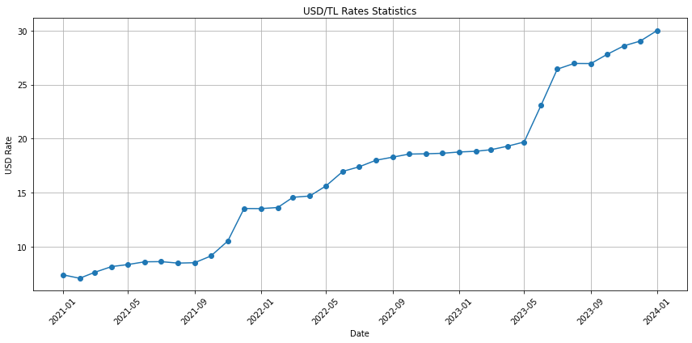

```python
plt.figure(figsize=(12, 6))
plt.plot(usd_rates.index, usd_rates['USD Rate'], marker='o')
plt.title('USD/TL Rates Statistics')
plt.xlabel('Date')
plt.ylabel('USD Rate')
plt.grid(True)
plt.xticks(rotation=45)
plt.tight_layout()

# Display the plot
plt.show()
```

### correlation check -1

```python
merged_df = pd.merge(house_sales, usd_rates, on='Date')
```

```python
merged_df['House Sales'] = pd.to_numeric(merged_df['House Sales'], errors='coerce')
merged_df['USD Rate'] = pd.to_numeric(merged_df['USD Rate'], errors='coerce')
```

```python
# Calculate the correlation between 'Sales' and 'USD Rate'
correlation = merged_df['House Sales'].corr(merged_df['USD Rate'])

print(f"The correlation between house sales and USD rate is: {correlation}")
```

```
The correlation between house sales and USD rate is: -0.11879598181305932
```

### Short-Term External Debt Stock (Million USD)

```python
file_path = 'C:/Users/Kaan Ertan/Desktop/ie360-hw1/external-debt-stock.xlsx'

external_debt = pd.read_excel(file_path, sheet_name='EVDS')
```

```python
external_debt
```

|  | Date | TP KVDB01 | Unnamed: 2 |
| --- | --- | --- | --- |
| 0 | 2021-01 | 22752 | NaN |
| 1 | 2021-02 | 22774 | NaN |
| 2 | 2021-03 | 22616 | NaN |
| 3 | 2021-04 | 22752 | NaN |
| 4 | 2021-05 | 22522 | NaN |
| 5 | 2021-06 | 25824 | NaN |
| 6 | 2021-07 | 26014 | NaN |
| 7 | 2021-08 | 25945 | NaN |
| 8 | 2021-09 | 25850 | NaN |
| 9 | 2021-10 | 26086 | NaN |
| 10 | 2021-11 | 26020 | NaN |
| 11 | 2021-12 | 26052 | NaN |
| 12 | 2022-01 | 27151 | NaN |
| 13 | 2022-02 | 29837 | NaN |
| 14 | 2022-03 | 29812 | NaN |
| 15 | 2022-04 | 29444 | NaN |
| 16 | 2022-05 | 29429 | NaN |
| 17 | 2022-06 | 29428 | NaN |
| 18 | 2022-07 | 29754 | NaN |
| 19 | 2022-08 | 31610 | NaN |
| 20 | 2022-09 | 31975 | NaN |
| 21 | 2022-10 | 32269 | NaN |
| 22 | 2022-11 | 32483 | NaN |
| 23 | 2022-12 | 32790 | NaN |
| 24 | 2023-01 | 33646 | NaN |
| 25 | 2023-02 | 33793 | NaN |
| 26 | 2023-03 | 39321 | NaN |
| 27 | 2023-04 | 40291 | NaN |
| 28 | 2023-05 | 44416 | NaN |
| 29 | 2023-06 | 46234 | NaN |
| 30 | 2023-07 | 46356 | NaN |
| 31 | 2023-08 | 45989 | NaN |
| 32 | 2023-09 | 45714 | NaN |
| 33 | 2023-10 | 45796 | NaN |
| 34 | 2023-11 | 46263 | NaN |
| 35 | 2023-12 | 46360 | NaN |
| 36 | 2024-01 | 46103 | NaN |
| 37 | NaN | NaN | NaN |
| 38 | NaN | NaN | NaN |
| 39 | Series Descriptions | NaN | NaN |
| 40 | TP.KVDB01 | 1. Central Bank (Milyon ABD Doları)-Level | Observation: End |
| 41 | NaN | NaN | NaN |
| 42 | Notes | NaN | NaN |
| 43 | TP.KVDB01 | Methodological Changes | https://wcm.tcmb.gov.tr/wps/wcm/connect/EN/TCM... |
| 44 | NaN | Datasource | CBRT |
| 45 | NaN | Data Release Calendar | http://www3.tcmb.gov.tr/veriyaytakvim/takvim.php |
| 46 | NaN | Metadata Link | http://www.tcmb.gov.tr/wps/wcm/connect/EN/TCMB... |
| 47 | NaN | Revision Policy | http://www.tcmb.gov.tr/wps/wcm/connect/EN/TCMB... |
| 48 | NaN | Tags | Gross, External, Debt, External, Debt |

```python
external_debt=external_debt.drop(columns=['Unnamed: 2'])
external_debt = external_debt.iloc[:37]
```

```python
external_debt.columns = ['Date', 'External Debt Stock']
external_debt['Date'] = pd.to_datetime(external_debt['Date'])
external_debt.set_index('Date', inplace=True)
```

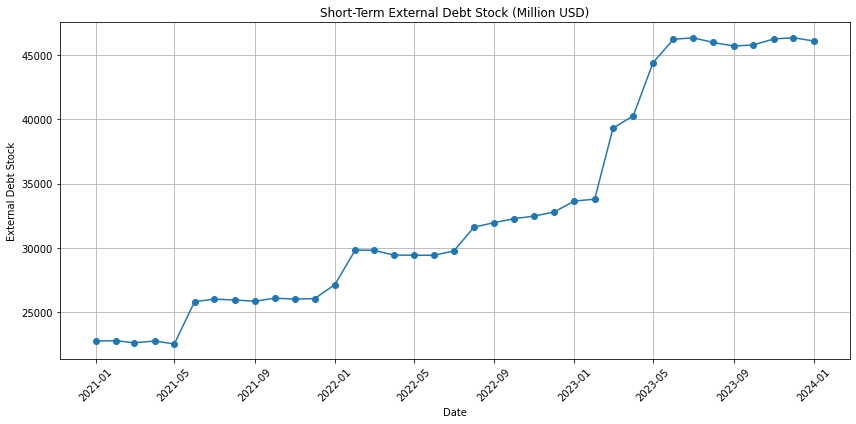

```python
plt.figure(figsize=(12, 6))
plt.plot(external_debt.index, external_debt['External Debt Stock'], marker='o')
plt.title('Short-Term External Debt Stock (Million USD)')
plt.xlabel('Date')
plt.ylabel('External Debt Stock')
plt.grid(True)
plt.xticks(rotation=45)
plt.tight_layout()

# Display the plot
plt.show()
```

### correlation check -2

```python
merged_df = pd.merge(merged_df, external_debt, on='Date')
```

```python
merged_df['External Debt Stock'] = pd.to_numeric(merged_df['External Debt Stock'], errors='coerce')
```

```python
correlation = merged_df['External Debt Stock'].corr(merged_df['USD Rate'])

print(f"The correlation between external debt stock and USD rate is: {correlation}")
```

```
The correlation between external debt stock and USD rate is: 0.946816410666216
```

As expected from the time series graphs above, these two are very correlated, so we will check for another time series data

### Gold Production of Mining Companies Declaration (Kg)

```python
file_path = 'C:/Users/Kaan Ertan/Desktop/ie360-hw1/gold_production.xlsx'

gold_production = pd.read_excel(file_path, sheet_name='EVDS')
print(gold_production.index[:5])
```

```
RangeIndex(start=0, stop=5, step=1)
```

```python
gold_production
```

|  | Tarih | TP URALTIN ALTINKG | Unnamed: 2 |
| --- | --- | --- | --- |
| 0 | 2021-01 | 3232.106 | NaN |
| 1 | 2021-02 | 2850.799 | NaN |
| 2 | 2021-03 | 3629.997 | NaN |
| 3 | 2021-04 | 2713.107 | NaN |
| 4 | 2021-05 | 3013.055 | NaN |
| 5 | 2021-06 | 3647.311 | NaN |
| 6 | 2021-07 | 3310.844 | NaN |
| 7 | 2021-08 | 3350.437 | NaN |
| 8 | 2021-09 | 3866.106 | NaN |
| 9 | 2021-10 | 3699.891 | NaN |
| 10 | 2021-11 | 3168.756 | NaN |
| 11 | 2021-12 | 2883.069 | NaN |
| 12 | 2022-01 | 3600.302 | NaN |
| 13 | 2022-02 | 2797.71 | NaN |
| 14 | 2022-03 | 3058.331 | NaN |
| 15 | 2022-04 | 2203.244 | NaN |
| 16 | 2022-05 | 2401.562 | NaN |
| 17 | 2022-06 | 2893.962 | NaN |
| 18 | 2022-07 | 2159.961 | NaN |
| 19 | 2022-08 | 2324.767 | NaN |
| 20 | 2022-09 | 2058.017 | NaN |
| 21 | 2022-10 | 2452.144 | NaN |
| 22 | 2022-11 | 2724.423 | NaN |
| 23 | 2022-12 | 2259.987 | NaN |
| 24 | 2023-01 | 2686.612 | NaN |
| 25 | 2023-02 | 2447.854 | NaN |
| 26 | 2023-03 | 2628.564 | NaN |
| 27 | 2023-04 | 2213.008 | NaN |
| 28 | 2023-05 | 2508.55 | NaN |
| 29 | 2023-06 | 2894.89 | NaN |
| 30 | 2023-07 | 3230.953 | NaN |
| 31 | 2023-08 | 3569.637 | NaN |
| 32 | 2023-09 | 3707.483 | NaN |
| 33 | 2023-10 | 3740.1 | NaN |
| 34 | 2023-11 | 3724.129 | NaN |
| 35 | 2023-12 | 3103.036 | NaN |
| 36 | 2024-01 | 3743.424 | NaN |
| 37 | NaN | NaN | NaN |
| 38 | NaN | NaN | NaN |
| 39 | Seri Açıklamaları | NaN | NaN |
| 40 | TP.URALTIN.ALTINKG | Maden Firmalarının Altın Üretim Bildirimleri(B... | Gözlem Değeri: Orijinal Gözlem |
| 41 | NaN | NaN | NaN |
| 42 | Notlar | NaN | NaN |
| 43 | TP.URALTIN.ALTINKG | Veri Kaynağı | BORSA İSTANBUL |
| 44 | NaN | Etiketler | Borsa, Altın, |

```python
gold_production=gold_production.drop(columns=['Unnamed: 2'])
gold_production = gold_production.iloc[:37]
```

```python
gold_production.columns = ['Date', 'Gold Production']
gold_production['Date'] = pd.to_datetime(gold_production['Date'])
gold_production.set_index('Date', inplace=True)
```

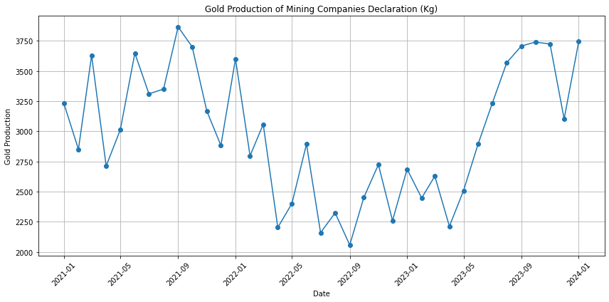

```python
plt.figure(figsize=(12, 6))
plt.plot(gold_production.index, gold_production['Gold Production'], marker='o')
plt.title('Gold Production of Mining Companies Declaration (Kg)')
plt.xlabel('Date')
plt.ylabel('Gold Production')
plt.grid(True)
plt.xticks(rotation=45)
plt.tight_layout()

# Display the plot
plt.show()
```

```python
merged_df
```

| Date | House Sales | USD Rate | External Debt Stock |
| --- | --- | --- | --- |
| 2021-01-01 | 70587 | 7.393975 | 22752 |
| 2021-02-01 | 81222 | 7.072365 | 22774 |
| 2021-03-01 | 111241 | 7.628235 | 22616 |
| 2021-04-01 | 95863 | 8.155024 | 22752 |
| 2021-05-01 | 59166 | 8.342250 | 22522 |
| 2021-06-01 | 134731 | 8.596682 | 25824 |
| 2021-07-01 | 107785 | 8.612941 | 26014 |
| 2021-08-01 | 141400 | 8.475714 | 25945 |
| 2021-09-01 | 147143 | 8.511882 | 25850 |
| 2021-10-01 | 137401 | 9.139945 | 26086 |
| 2021-11-01 | 178814 | 10.523264 | 26020 |
| 2021-12-01 | 226503 | 13.528496 | 26052 |
| 2022-01-01 | 88306 | 13.519262 | 27151 |
| 2022-02-01 | 97587 | 13.621125 | 29837 |
| 2022-03-01 | 134170 | 14.565609 | 29812 |
| 2022-04-01 | 133058 | 14.683567 | 29444 |
| 2022-05-01 | 122768 | 15.623922 | 29429 |
| 2022-06-01 | 150509 | 16.964718 | 29428 |
| 2022-07-01 | 93902 | 17.387417 | 29754 |
| 2022-08-01 | 123491 | 17.994950 | 31610 |
| 2022-09-01 | 113402 | 18.281477 | 31975 |
| 2022-10-01 | 102660 | 18.564614 | 32269 |
| 2022-11-01 | 117806 | 18.590895 | 32483 |
| 2022-12-01 | 207963 | 18.636968 | 32790 |
| 2023-01-01 | 97708 | 18.757573 | 33646 |
| 2023-02-01 | 80031 | 18.823310 | 33793 |
| 2023-03-01 | 105476 | 18.969309 | 39321 |
| 2023-04-01 | 85652 | 19.302253 | 40291 |
| 2023-05-01 | 113276 | 19.684048 | 44416 |
| 2023-06-01 | 83636 | 23.064489 | 46234 |
| 2023-07-01 | 109548 | 26.422738 | 46356 |
| 2023-08-01 | 122091 | 26.950577 | 45989 |
| 2023-09-01 | 102656 | 26.940919 | 45714 |
| 2023-10-01 | 93761 | 27.796032 | 45796 |
| 2023-11-01 | 93514 | 28.585586 | 46263 |
| 2023-12-01 | 138577 | 29.022562 | 46360 |
| 2024-01-01 | 80308 | 29.999700 | 46103 |

### correlation check -3

```python
merged_df=merged_df.drop(columns=['External Debt Stock'])
#merged_df=merged_df.drop(columns=['External Debt Stock_y'])
```

```python
merged_df = pd.merge(merged_df, gold_production, on='Date')
```

```python
merged_df['Gold Production'] = pd.to_numeric(merged_df['Gold Production'], errors='coerce')
```

```python
correlation = merged_df['Gold Production'].corr(merged_df['USD Rate'])

print(f"The correlation between gold production and USD rate is: {correlation}")
```

```
The correlation between gold production and USD rate is: 0.025754108912059825
```

```python
correlation = merged_df['Gold Production'].corr(merged_df['House Sales'])

print(f"The correlation between gold production and house sales is: {correlation}")
```

```
The correlation between gold production and house sales is: -0.043385802868678394
```

```python
merged_df
```

| Date | House Sales | USD Rate | Gold Production |
| --- | --- | --- | --- |
| 2021-01-01 | 70587 | 7.393975 | 3232.106 |
| 2021-02-01 | 81222 | 7.072365 | 2850.799 |
| 2021-03-01 | 111241 | 7.628235 | 3629.997 |
| 2021-04-01 | 95863 | 8.155024 | 2713.107 |
| 2021-05-01 | 59166 | 8.342250 | 3013.055 |
| 2021-06-01 | 134731 | 8.596682 | 3647.311 |
| 2021-07-01 | 107785 | 8.612941 | 3310.844 |
| 2021-08-01 | 141400 | 8.475714 | 3350.437 |
| 2021-09-01 | 147143 | 8.511882 | 3866.106 |
| 2021-10-01 | 137401 | 9.139945 | 3699.891 |
| 2021-11-01 | 178814 | 10.523264 | 3168.756 |
| 2021-12-01 | 226503 | 13.528496 | 2883.069 |
| 2022-01-01 | 88306 | 13.519262 | 3600.302 |
| 2022-02-01 | 97587 | 13.621125 | 2797.710 |
| 2022-03-01 | 134170 | 14.565609 | 3058.331 |
| 2022-04-01 | 133058 | 14.683567 | 2203.244 |
| 2022-05-01 | 122768 | 15.623922 | 2401.562 |
| 2022-06-01 | 150509 | 16.964718 | 2893.962 |
| 2022-07-01 | 93902 | 17.387417 | 2159.961 |
| 2022-08-01 | 123491 | 17.994950 | 2324.767 |
| 2022-09-01 | 113402 | 18.281477 | 2058.017 |
| 2022-10-01 | 102660 | 18.564614 | 2452.144 |
| 2022-11-01 | 117806 | 18.590895 | 2724.423 |
| 2022-12-01 | 207963 | 18.636968 | 2259.987 |
| 2023-01-01 | 97708 | 18.757573 | 2686.612 |
| 2023-02-01 | 80031 | 18.823310 | 2447.854 |
| 2023-03-01 | 105476 | 18.969309 | 2628.564 |
| 2023-04-01 | 85652 | 19.302253 | 2213.008 |
| 2023-05-01 | 113276 | 19.684048 | 2508.550 |
| 2023-06-01 | 83636 | 23.064489 | 2894.890 |
| 2023-07-01 | 109548 | 26.422738 | 3230.953 |
| 2023-08-01 | 122091 | 26.950577 | 3569.637 |
| 2023-09-01 | 102656 | 26.940919 | 3707.483 |
| 2023-10-01 | 93761 | 27.796032 | 3740.100 |
| 2023-11-01 | 93514 | 28.585586 | 3724.129 |
| 2023-12-01 | 138577 | 29.022562 | 3103.036 |
| 2024-01-01 | 80308 | 29.999700 | 3743.424 |

Now our data is ready with each combination of two having less correlation than 0.5 three year range, monthly

```python
import numpy as np
cols = ['House Sales', 'USD Rate', 'Gold Production']

# Calculate correlation matrix
corr_matrix = merged_df[cols].corr()

corr_matrix.values[np.triu_indices_from(corr_matrix, 0)] = np.nan

corr_df = corr_matrix.stack().reset_index()
corr_df.columns = ['Variable 1', 'Variable 2', 'Correlation']

corr_df
```

|  | Variable 1 | Variable 2 | Correlation |
| --- | --- | --- | --- |
| 0 | USD Rate | House Sales | -0.118796 |
| 1 | Gold Production | House Sales | -0.043386 |
| 2 | Gold Production | USD Rate | 0.025754 |

## Google Trends Analysis

##### Here I searched through various keywords to find the ones that have a large enough data pool in Google Trends. It is essential that these keywords' data is large enough so that trends and patterns can be seen and interpreted. In the following section I analyse these charts to find the best fit for my research models. (For simplicity only the Google Trends charts of those keywords that I chose can be seen here, but the others can be found within the homework folder)

### House Sales keyword analysis:

The "ev kredisi" (mortgage) search trend has a couple of very pronounced spikes, but they don't appear to align regularly or match the frequency of the house sales data.

The "emlak" (real estate) search trend shows more frequent fluctuations which seem to somewhat match the overall activity of the house sales data, with notable activity around the same times as some peaks in the house sales data.

The "mahalle" (neighborhood) search trend doesn't show pronounced spikes like the house sales data. It seems to have a general steady interest with one significant peak, not regularly matching the house sales data.

The "gayrimenkul yatırım" (real estate investment) search trend displays occasional spikes in interest, with a significant spike towards the end of the period that might correlate with a spike in house sales, but overall, the correlation seems weaker.

The "faiz" (interest rate) search trend shows periodic spikes. Some of these spikes could potentially correspond to the fluctuations in house sales, but the peaks are much more frequent and less pronounced than the house sales data.

Among these, the "emlak" trend shows the most similar behavior to the house sales data, with several peaks that might correspond to those in the house sales statistics. It's worth noting that correlation in trends does not imply causation, and these observations are purely on pattern similarity. The actual relationships between these trends could be influenced by a variety of factors.

##### Therefore, my research question is:

##### Is the Turkish house sales statistics related to the online search for "emlak" (real estate) in Türkiye?

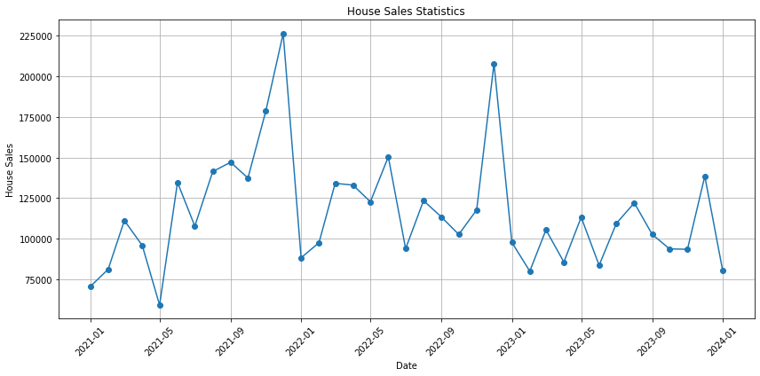

```python
plt.figure(figsize=(12, 6))
plt.plot(house_sales.index, house_sales['House Sales'], marker='o')
plt.title('House Sales Statistics')
plt.xlabel('Date')
plt.ylabel('House Sales')
plt.grid(True)
plt.xticks(rotation=45)
plt.tight_layout()

# Display the plot
plt.show()
```

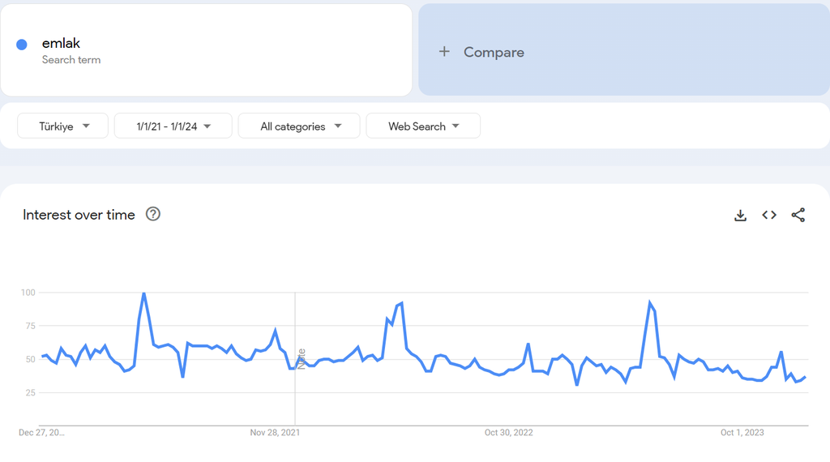

### USD rates keyword analysis:

"merkez bankası" (central bank): The graph shows some spikes in interest, but the overall trend doesn't closely follow the gradual increase seen in the USD/TL rate chart.

"tcmb" (abbreviation for Turkey's central bank): This search trend is similar to "merkez bankası" and does not reflect the consistent uptrend of the USD/TL rate.

"abd" (USA): The interest here shows volatility but not a significant consistent rise like the currency rate data.

"savaş" (war): Shows spikes in interest which are not in line with the gradual increase of the USD/TL rate.

"faiz kararı" (interest rate decision): This trend contains fluctuations that don't match the steady rise of the USD/TL rate.

"merkez bankası faiz" (central bank interest): The interest over time spikes periodically and doesn't show a gradual rise that corresponds with the USD/TL rate graph.

"yatırım" (investment): There is an increase in search interest over time, but the pattern does not closely match the USD/TL graph's trend.

"enflasyon" (inflation): The trend here is quite volatile with sharp spikes, not resembling the steady uptrend of the USD/TL rate.

"dolar kuru" (dollar exchange rate): From the shape of the graph, it shows a notable spike at one point, which could correspond to a significant event or change in the exchange rate. Otherwise, it appears relatively stable with some fluctuations. However, the search trend graph does not appear to display the same gradual and consistent increase over time followed by a sharp rise towards the end as the USD/TL rate graph does. The correlation here may be more event-driven, associated with specific incidents that caused public interest to spike temporarily.

Among these, the "dolar kuru" trend shows the most similar behavior to the USD Rates data. Again, it is worth noting that correlation in trends does not imply causation, and these observations are purely on pattern similarity. The actual relationships between these trends could be influenced by a variety of factors.

##### Therefore, my research question is:

##### Is USD rate to TRY related to the online search for "dolar kuru" (dollar exchange rate) in Türkiye?

[figure not shown]

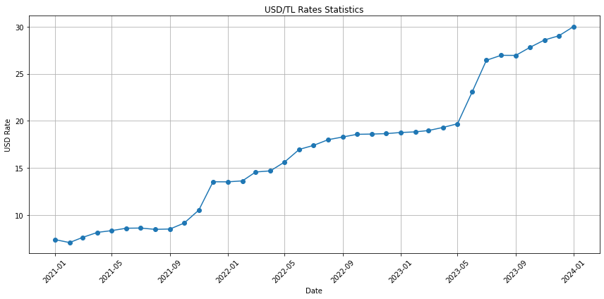

```python
plt.figure(figsize=(12, 6))
plt.plot(usd_rates.index, usd_rates['USD Rate'], marker='o')
plt.title('USD/TL Rates Statistics')
plt.xlabel('Date')
plt.ylabel('USD Rate')
plt.grid(True)
plt.xticks(rotation=45)
plt.tight_layout()

# Display the plot
plt.show()
```

### Gold production keyword analysis:

The "altın fiyat" (gold price) search trend shows fluctuations that are common in search trends related to commodity prices. The trend seems to have some correlation with the gold production graph in terms of variability but lacks a sustained rise towards the end.

The "madencilik" (mining) search trend has some significant peaks, potentially indicating increased interest during certain events or developments in the mining sector. This graph does not exhibit a sustained increase that aligns with the rise in the gold production graph.

The "altın bulundu" (gold found) search trend has several spikes which might be related to news events or discoveries in gold mining. It does not show a steady increase or a pattern that matches the gold production graph.

The "altın yatırım" (gold investment) search trend shows an increase in interest over time with some fluctuations. It doesn't have the sharp rise towards the end like the gold production graph, but the overall increase could suggest a correlation.

Considering the overall trends, "altın yatırım" could potentially have the most similar behavior to the gold production graph, as both involve the notion of gold and show a general increase over time.

##### Therefore, my research question is:

##### Are the declared gold production rates of companies related to the online search for "altın yatırım" (gold investment) in Türkiye?

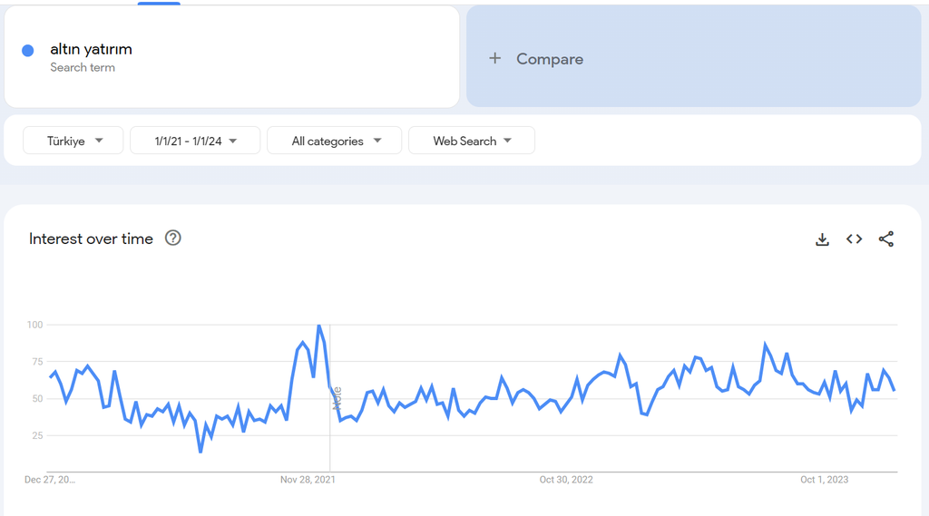

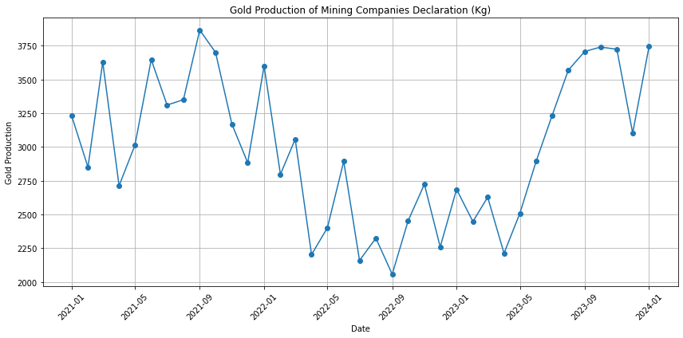

```python
plt.figure(figsize=(12, 6))
plt.plot(gold_production.index, gold_production['Gold Production'], marker='o')
plt.title('Gold Production of Mining Companies Declaration (Kg)')
plt.xlabel('Date')
plt.ylabel('Gold Production')
plt.grid(True)
plt.xticks(rotation=45)
plt.tight_layout()

# Display the plot
plt.show()
```

## Time Series Analysis

### House Sales

#### Keyword data pre-process steps

```python
file_path = 'C:/Users/Kaan Ertan/Desktop/ie360-hw1/emlak.csv'

emlak = pd.read_csv(file_path)
```

```python
emlak
```

|  | Kategori: Tüm kategoriler |
| --- | --- |
| Hafta | emlak: (Türkiye) |
| 2020-12-27 | 55 |
| 2021-01-03 | 56 |
| 2021-01-10 | 51 |
| 2021-01-17 | 51 |
| ... | ... |
| 2023-12-03 | 35 |
| 2023-12-10 | 40 |
| 2023-12-17 | 36 |
| 2023-12-24 | 36 |
| 2023-12-31 | 38 |

159 rows × 1 columns

```python
emlak.reset_index(inplace=True)
print("Columns in the DataFrame: ", emlak.columns.tolist())
```

```
Columns in the DataFrame:  ['index', 'Kategori: Tüm kategoriler']
```

```python
print(emlak["index"])
```

```
0           Hafta
1      2020-12-27
2      2021-01-03
3      2021-01-10
4      2021-01-17
          ...
154    2023-12-03
155    2023-12-10
156    2023-12-17
157    2023-12-24
158    2023-12-31
Name: index, Length: 159, dtype: object
```

```python
emlak.rename(columns={'index': 'Hafta'}, inplace=True)
```

```python
print(emlak["Hafta"])
```

```
0           Hafta
1      2020-12-27
2      2021-01-03
3      2021-01-10
4      2021-01-17
          ...
154    2023-12-03
155    2023-12-10
156    2023-12-17
157    2023-12-24
158    2023-12-31
Name: Hafta, Length: 159, dtype: object
```

```python
emlak = emlak.iloc[1:]

emlak['Hafta'] = pd.to_datetime(emlak['Hafta'])
```

```python
emlak
```

|  | Hafta | Kategori: Tüm kategoriler |
| --- | --- | --- |
| 1 | 2020-12-27 | 55 |
| 2 | 2021-01-03 | 56 |
| 3 | 2021-01-10 | 51 |
| 4 | 2021-01-17 | 51 |
| 5 | 2021-01-24 | 60 |
| ... | ... | ... |
| 154 | 2023-12-03 | 35 |
| 155 | 2023-12-10 | 40 |
| 156 | 2023-12-17 | 36 |
| 157 | 2023-12-24 | 36 |
| 158 | 2023-12-31 | 38 |

158 rows × 2 columns

```python
emlak.set_index('Hafta', inplace=True)

# Group by month and aggregate the weekly data. Choose the aggregation method: sum, mean, etc.
emlak_monthly = emlak.resample('M').sum()
```

```python
house_sales.index = house_sales.index.to_period('M').to_timestamp('M')
emlak.index = emlak.index.to_period('M').to_timestamp('M')
```

```python
combined_data = house_sales.join(emlak, how='inner')
```

```python
combined_data
```

|  | House Sales | Kategori: Tüm kategoriler |
| --- | --- | --- |
| 2021-01-31 | 70587 | 56 |
| 2021-01-31 | 70587 | 51 |
| 2021-01-31 | 70587 | 51 |
| 2021-01-31 | 70587 | 60 |
| 2021-01-31 | 70587 | 57 |
| ... | ... | ... |
| 2023-12-31 | 138577 | 35 |
| 2023-12-31 | 138577 | 40 |
| 2023-12-31 | 138577 | 36 |
| 2023-12-31 | 138577 | 36 |
| 2023-12-31 | 138577 | 38 |

157 rows × 2 columns

```python
emlak_grouped = combined_data.groupby(combined_data.index)['Kategori: Tüm kategoriler'].sum()


combined_data = combined_data[~combined_data.index.duplicated(keep='first')]


final_combined_data = combined_data[['House Sales']].copy()
final_combined_data['Emlak Trends Sum'] = emlak_grouped
```

```python
final_combined_data
```

|  | House Sales | Emlak Trends Sum |
| --- | --- | --- |
| 2021-01-31 | 70587 | 5651516057 |
| 2021-02-28 | 81222 | 55475459 |
| 2021-03-31 | 111241 | 56625564 |
| 2021-04-30 | 95863 | 55504944 |
| 2021-05-31 | 59166 | 4346849489 |
| 2021-06-30 | 134731 | 60626563 |
| 2021-07-31 | 107785 | 61604161 |
| 2021-08-31 | 141400 | 6162626462 |
| 2021-09-30 | 147143 | 65605963 |
| 2021-10-31 | 137401 | 5754535258 |
| 2021-11-30 | 178814 | 58606777 |
| 2021-12-31 | 226503 | 60594445 |
| 2022-01-31 | 88306 | 5349474849 |
| 2022-02-28 | 97587 | 52525250 |
| 2022-03-31 | 134170 | 50545963 |
| 2022-04-30 | 133058 | 52555650 |
| 2022-05-31 | 122768 | 52818094100 |
| 2022-06-30 | 150509 | 62555450 |
| 2022-07-31 | 93902 | 4343535555 |
| 2022-08-31 | 123491 | 50514746 |
| 2022-09-30 | 113402 | 45534644 |
| 2022-10-31 | 102660 | 4242404046 |
| 2022-11-30 | 117806 | 44484866 |
| 2022-12-31 | 207963 | 43424341 |
| 2023-01-31 | 97708 | 5452575447 |
| 2023-02-28 | 80031 | 32465450 |
| 2023-03-31 | 105476 | 47484345 |
| 2023-04-30 | 85652 | 4442354446 |
| 2023-05-31 | 113276 | 47699688 |
| 2023-06-30 | 83636 | 51535038 |
| 2023-07-31 | 109548 | 5556534953 |
| 2023-08-31 | 122091 | 48454545 |
| 2023-09-30 | 102656 | 44444341 |
| 2023-10-31 | 93761 | 3638373836 |
| 2023-11-30 | 93514 | 39424659 |
| 2023-12-31 | 138577 | 3540363638 |

#### Time series

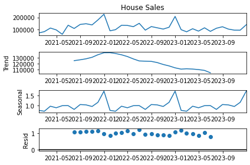

```python
import pandas as pd
import numpy as np
from statsmodels.tsa.seasonal import seasonal_decompose
from statsmodels.tsa.statespace.sarimax import SARIMAX
import matplotlib.pyplot as plt


# Decompose the time series into trend, seasonal, and residual components
decomposition = seasonal_decompose(final_combined_data['House Sales'], model='multiplicative', period=12)

# Plot the decomposed components
decomposition.plot()
plt.show()
```

[figure not shown]

```python
import pandas as pd
import numpy as np
import matplotlib.pyplot as plt
from statsmodels.graphics.tsaplots import plot_acf, plot_pacf
fig, ax = plt.subplots(2, 1, figsize=(10, 6))
plot_acf(final_combined_data['House Sales'], ax=ax[0])
plt.show()
```

#### Model with identified lags

```python
import pandas as pd
from statsmodels.tsa.stattools import adfuller
from statsmodels.regression.linear_model import OLS
from statsmodels.tools import add_constant

final_combined_data['Lag1'] = final_combined_data['House Sales'].shift(1)
final_combined_data['Lag3'] = final_combined_data['House Sales'].shift(3)
final_combined_data['Lag4'] = final_combined_data['House Sales'].shift(4)
final_combined_data['Lag6'] = final_combined_data['House Sales'].shift(6)
final_combined_data['Lag2'] = final_combined_data['House Sales'].shift(2)

final_combined_data['Lag12'] = final_combined_data['House Sales'].shift(12)  # This is a yearly lag, adjust according to your data frequency


final_combined_data['Lag1_keyword'] = final_combined_data['Emlak Trends Sum'].shift(1)
final_combined_data['Lag12_keyword'] = final_combined_data['Emlak Trends Sum'].shift(12)  # This is a yearly lag, adjust according to your data frequency

final_combined_data.dropna(inplace=True)
```

```python
final_combined_data['House Sales'] = pd.to_numeric(final_combined_data['House Sales'], errors='coerce')
final_combined_data['Lag1'] = pd.to_numeric(final_combined_data['Lag1'], errors='coerce')
final_combined_data['Lag2'] = pd.to_numeric(final_combined_data['Lag2'], errors='coerce')

final_combined_data['Lag3'] = pd.to_numeric(final_combined_data['Lag3'], errors='coerce')
final_combined_data['Lag4'] = pd.to_numeric(final_combined_data['Lag4'], errors='coerce')
final_combined_data['Lag6'] = pd.to_numeric(final_combined_data['Lag6'], errors='coerce')

final_combined_data['Lag12'] = pd.to_numeric(final_combined_data['Lag12'], errors='coerce')
final_combined_data['Lag1_keyword'] = pd.to_numeric(final_combined_data['Lag1_keyword'], errors='coerce')
final_combined_data['Lag12_keyword'] = pd.to_numeric(final_combined_data['Lag12_keyword'], errors='coerce')
```

```python
X = final_combined_data[['Lag1', 'Lag12','Lag3','Lag4','Lag6']]
y = final_combined_data['House Sales']

# Add a constant to the model (the intercept term)
X = add_constant(X)

# Fit the model
model = OLS(y, X).fit()

# Output the summary of the model
print(model.summary())
```

```
                            OLS Regression Results
==============================================================================
Dep. Variable:            House Sales   R-squared:                       0.416
Model:                            OLS   Adj. R-squared:                  0.254
Method:                 Least Squares   F-statistic:                     2.566
Date:                Fri, 05 Apr 2024   Prob (F-statistic):             0.0639
Time:                        21:52:40   Log-Likelihood:                -272.43
No. Observations:                  24   AIC:                             556.9
Df Residuals:                      18   BIC:                             563.9
Df Model:                           5
Covariance Type:            nonrobust
==============================================================================
                 coef    std err          t      P>|t|      [0.025      0.975]
------------------------------------------------------------------------------
const       1.778e+04   3.97e+04      0.448      0.660   -6.57e+04    1.01e+05
Lag1           0.0629      0.151      0.417      0.682      -0.254       0.380
Lag12          0.4181      0.134      3.123      0.006       0.137       0.699
Lag3           0.0152      0.138      0.110      0.914      -0.275       0.306
Lag4           0.0847      0.137      0.619      0.544      -0.203       0.373
Lag6           0.1898      0.135      1.411      0.175      -0.093       0.472
==============================================================================
Omnibus:                        1.473   Durbin-Watson:                   1.969
Prob(Omnibus):                  0.479   Jarque-Bera (JB):                0.394
Skew:                          -0.161   Prob(JB):                        0.821
Kurtosis:                       3.539   Cond. No.                     2.26e+06
==============================================================================

Notes:
[1] Standard Errors assume that the covariance matrix of the errors is correctly specified.
[2] The condition number is large, 2.26e+06. This might indicate that there are
strong multicollinearity or other numerical problems.
```

#### Residual analysis

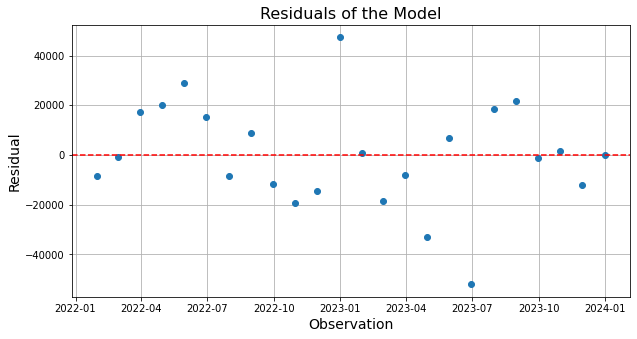

```python
predictions = model.predict(X)

# Calculate the residuals
residuals = y - predictions

# Plotting residuals
plt.figure(figsize=(10, 5))
plt.plot(residuals, marker='o', linestyle='')
plt.title('Residuals of the Model', fontsize=16)
plt.xlabel('Observation', fontsize=14)
plt.ylabel('Residual', fontsize=14)
plt.axhline(y=0, color='r', linestyle='--')
plt.grid(True)
plt.show()
```

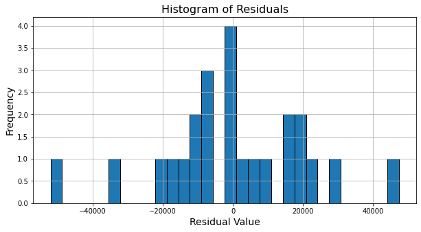

```python
# Histogram of the residuals
plt.figure(figsize=(10, 5))
plt.hist(residuals, bins=30, edgecolor='k')
plt.title('Histogram of Residuals', fontsize=16)
plt.xlabel('Residual Value', fontsize=14)
plt.ylabel('Frequency', fontsize=14)
plt.grid(True)
plt.show()
```

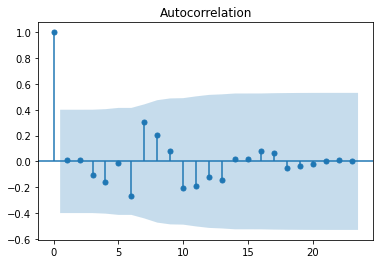

```python
import statsmodels.api as sm

n_obs = len(residuals)

# Set the number of lags to the minimum of 40 or n_obs-1
n_lags = min(40, n_obs - 1)

# Checking for autocorrelation of residuals with the appropriate number of lags
fig = sm.graphics.tsa.plot_acf(residuals, lags=n_lags)
plt.show()
```

```
d:\Programlar D\Anaconda\lib\site-packages\statsmodels\graphics\gofplots.py:993: UserWarning: marker is redundantly defined by the 'marker' keyword argument and the fmt string "bo" (-> marker='o'). The keyword argument will take precedence.
  ax.plot(x, y, fmt, **plot_style)
```

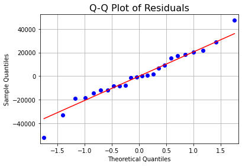

```python
import statsmodels.api as sm

# Checking for normality of residuals
sm.qqplot(residuals, line='s')
plt.title('Q-Q Plot of Residuals', fontsize=16)
plt.grid(True)
plt.show()
```

#### Analysis for the chosen model

R-squared: The R-squared is 0.416, meaning the model explains about 41.6% of the variability in house sales.

Residual Analysis:

Residual Plot: The scatter of residuals around the zero line appears random without any clear pattern or systematic deviation. Residuals seem to display constant variance and zero mean, following a near normal distribution.

Histogram of Residuals: The residuals seem more evenly distributed around zero, although there's still some asymmetry. This distribution looks more like a normal distribution compared to the previous models but is not perfect. However, from the trials of different models, this one resulted the best residuals so far.

Autocorrelation: The autocorrelation plot shows most of the spikes within the confidence band, which indicates less autocorrelation of significance.

Q-Q Plot: The points in the Q-Q plot lie closer to the line, particularly in the center of the distribution, suggesting that the residuals are normally distributed, although there are still deviations in the tails.

Significance of Coefficients:

The variable Lag12 remains statistically significant with a p-value of 0.006, reinforcing the potential seasonal effect on house sales.

The coefficients for Lag1, Lag3, Lag4, and Lag6 have high p-values, suggesting they are not statistically significant and may not be contributing meaningful information to the model.

## Dolar Rates Time Series Analysis

#### Keyword Data Preprocessing

```python
file_path = 'C:/Users/Kaan Ertan/Desktop/ie360-hw1/dolar.csv'

dolar_tl = pd.read_csv(file_path)
```

```python
dolar_tl
```

|  | Kategori: Tüm kategoriler |
| --- | --- |
| Hafta | dolar kuru: (Türkiye) |
| 2020-12-27 | 6 |
| 2021-01-03 | 6 |
| 2021-01-10 | 5 |
| 2021-01-17 | 5 |
| ... | ... |
| 2023-12-03 | 7 |
| 2023-12-10 | 8 |
| 2023-12-17 | 7 |
| 2023-12-24 | 8 |
| 2023-12-31 | 8 |

159 rows × 1 columns

```python
dolar_tl.reset_index(inplace=True)
print("Columns in the DataFrame: ", dolar_tl.columns.tolist())
```

```
Columns in the DataFrame:  ['index', 'Kategori: Tüm kategoriler']
```

```python
dolar_tl.rename(columns={'index': 'Hafta'}, inplace=True)
```

```python
dolar_tl
```

|  | Hafta | Kategori: Tüm kategoriler |
| --- | --- | --- |
| 0 | Hafta | dolar kuru: (Türkiye) |
| 1 | 2020-12-27 | 6 |
| 2 | 2021-01-03 | 6 |
| 3 | 2021-01-10 | 5 |
| 4 | 2021-01-17 | 5 |
| ... | ... | ... |
| 154 | 2023-12-03 | 7 |
| 155 | 2023-12-10 | 8 |
| 156 | 2023-12-17 | 7 |
| 157 | 2023-12-24 | 8 |
| 158 | 2023-12-31 | 8 |

159 rows × 2 columns

```python
dolar_tl = dolar_tl.iloc[1:]
dolar_tl
```

|  | Hafta | Kategori: Tüm kategoriler |
| --- | --- | --- |
| 1 | 2020-12-27 | 6 |
| 2 | 2021-01-03 | 6 |
| 3 | 2021-01-10 | 5 |
| 4 | 2021-01-17 | 5 |
| 5 | 2021-01-24 | 4 |
| ... | ... | ... |
| 154 | 2023-12-03 | 7 |
| 155 | 2023-12-10 | 8 |
| 156 | 2023-12-17 | 7 |
| 157 | 2023-12-24 | 8 |
| 158 | 2023-12-31 | 8 |

158 rows × 2 columns

```python
dolar_tl['Hafta'] = pd.to_datetime(dolar_tl['Hafta'])
```

```python
dolar_tl.set_index('Hafta', inplace=True)

# Group by month and aggregate the weekly data. Choose the aggregation method: sum, mean, etc.
dolar_tl_monthly = dolar_tl.resample('M').sum()
```

```python
dolar_tl_monthly.rename(columns={'Kategori: Tüm kategoriler': 'monthly_keyword'}, inplace=True)

dolar_tl_monthly
```

| Hafta | monthly_keyword |
| --- | --- |
| 2020-12-31 | 6 |
| 2021-01-31 | 65546 |
| 2021-02-28 | 5677 |
| 2021-03-31 | 762614 |
| 2021-04-30 | 8787 |
| 2021-05-31 | 55668 |
| 2021-06-30 | 6775 |
| 2021-07-31 | 5544 |
| 2021-08-31 | 65555 |
| 2021-09-30 | 6588 |
| 2021-10-31 | 713161410 |
| 2021-11-30 | 14294434 |
| 2021-12-31 | 244710056 |
| 2022-01-31 | 3623191616 |
| 2022-02-28 | 14132420 |
| 2022-03-31 | 21171313 |
| 2022-04-30 | 1110910 |
| 2022-05-31 | 1119202418 |
| 2022-06-30 | 28201821 |
| 2022-07-31 | 1717171714 |
| 2022-08-31 | 11141413 |
| 2022-09-30 | 11111415 |
| 2022-10-31 | 13111099 |
| 2022-11-30 | 10987 |
| 2022-12-31 | 7778 |
| 2023-01-31 | 87766 |
| 2023-02-28 | 4555 |
| 2023-03-31 | 6667 |
| 2023-04-30 | 87887 |
| 2023-05-31 | 10111122 |
| 2023-06-30 | 36212721 |
| 2023-07-31 | 2016231513 |
| 2023-08-31 | 12112013 |
| 2023-09-30 | 11111211 |
| 2023-10-31 | 1111121117 |
| 2023-11-30 | 10898 |
| 2023-12-31 | 78788 |

```python
usd_rates.index = usd_rates.index.to_period('M').to_timestamp('M')
dolar_tl_monthly.index = dolar_tl_monthly.index.to_period('M').to_timestamp('M')
combined_data2 = usd_rates.join(dolar_tl_monthly, how='inner')
```

```python
import statsmodels.api as sm
import matplotlib.pyplot as plt
from statsmodels.tsa.seasonal import seasonal_decompose
```

#### Time series

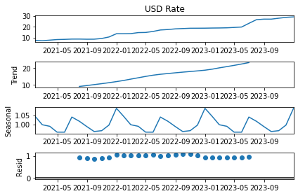

```python
import pandas as pd
import numpy as np
from statsmodels.tsa.seasonal import seasonal_decompose
from statsmodels.tsa.statespace.sarimax import SARIMAX
import matplotlib.pyplot as plt


# Decompose the time series into trend, seasonal, and residual components
decomposition = seasonal_decompose(combined_data2['USD Rate'], model='multiplicative', period=12)

# Plot the decomposed components
decomposition.plot()
plt.show()
```

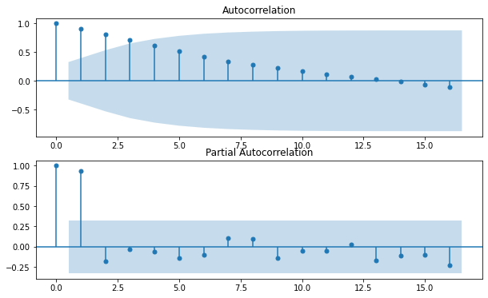

```python
import pandas as pd
import numpy as np
import matplotlib.pyplot as plt
from statsmodels.graphics.tsaplots import plot_acf, plot_pacf
fig, ax = plt.subplots(2, 1, figsize=(10, 6))
plot_acf(combined_data2['USD Rate'], ax=ax[0])
plot_pacf(combined_data2['USD Rate'], ax=ax[1])
plt.show()
```

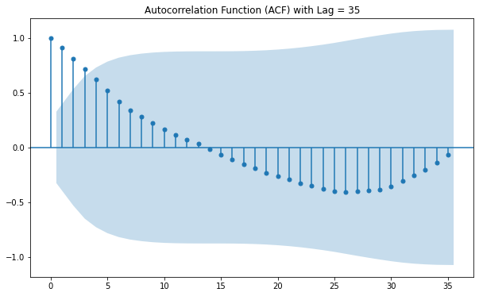

```python
import matplotlib.pyplot as plt
from statsmodels.graphics.tsaplots import plot_acf

plt.figure(figsize=(10, 6))
plot_acf(combined_data2['USD Rate'], lags=35, ax=plt.gca())
plt.title('Autocorrelation Function (ACF) with Lag = 35')
plt.show()
```

```python
combined_data2
```

|  | USD Rate | monthly_keyword |
| --- | --- | --- |
| 2021-01-31 | 7.393975 | 65546 |
| 2021-02-28 | 7.072365 | 5677 |
| 2021-03-31 | 7.628235 | 762614 |
| 2021-04-30 | 8.155024 | 8787 |
| 2021-05-31 | 8.34225 | 55668 |
| 2021-06-30 | 8.596682 | 6775 |
| 2021-07-31 | 8.612941 | 5544 |
| 2021-08-31 | 8.475714 | 65555 |
| 2021-09-30 | 8.511882 | 6588 |
| 2021-10-31 | 9.139945 | 713161410 |
| 2021-11-30 | 10.523264 | 14294434 |
| 2021-12-31 | 13.528496 | 244710056 |
| 2022-01-31 | 13.519262 | 3623191616 |
| 2022-02-28 | 13.621125 | 14132420 |
| 2022-03-31 | 14.565609 | 21171313 |
| 2022-04-30 | 14.683567 | 1110910 |
| 2022-05-31 | 15.623922 | 1119202418 |
| 2022-06-30 | 16.964718 | 28201821 |
| 2022-07-31 | 17.387417 | 1717171714 |
| 2022-08-31 | 17.99495 | 11141413 |
| 2022-09-30 | 18.281477 | 11111415 |
| 2022-10-31 | 18.564614 | 13111099 |
| 2022-11-30 | 18.590895 | 10987 |
| 2022-12-31 | 18.636968 | 7778 |
| 2023-01-31 | 18.757573 | 87766 |
| 2023-02-28 | 18.82331 | 4555 |
| 2023-03-31 | 18.969309 | 6667 |
| 2023-04-30 | 19.302253 | 87887 |
| 2023-05-31 | 19.684048 | 10111122 |
| 2023-06-30 | 23.064489 | 36212721 |
| 2023-07-31 | 26.422738 | 2016231513 |
| 2023-08-31 | 26.950577 | 12112013 |
| 2023-09-30 | 26.940919 | 11111211 |
| 2023-10-31 | 27.796032 | 1111121117 |
| 2023-11-30 | 28.585586 | 10898 |
| 2023-12-31 | 29.022562 | 78788 |

#### Model with identified lags

```python
import pandas as pd
from statsmodels.tsa.stattools import adfuller
from statsmodels.regression.linear_model import OLS
from statsmodels.tools import add_constant

combined_data2['Lag1'] = combined_data2['USD Rate'].shift(1)
combined_data2['Lag3'] = combined_data2['USD Rate'].shift(3)
combined_data2['Lag4'] = combined_data2['USD Rate'].shift(4)
combined_data2['Lag6'] = combined_data2['USD Rate'].shift(6)

combined_data2['Lag12'] = combined_data2['USD Rate'].shift(12)  # This is a yearly lag, adjust according to your data frequency


combined_data2['Lag1_keyword'] = combined_data2['monthly_keyword'].shift(1)
combined_data2['Lag12_keyword'] = combined_data2['monthly_keyword'].shift(12)  # This is a yearly lag, adjust according to your data frequency

combined_data2.dropna(inplace=True)
```

```python
combined_data2['USD Rate'] = pd.to_numeric(combined_data2['USD Rate'], errors='coerce')
combined_data2['Lag1'] = pd.to_numeric(combined_data2['Lag1'], errors='coerce')
combined_data2['Lag3'] = pd.to_numeric(combined_data2['Lag3'], errors='coerce')
combined_data2['Lag4'] = pd.to_numeric(combined_data2['Lag4'], errors='coerce')
combined_data2['Lag6'] = pd.to_numeric(combined_data2['Lag6'], errors='coerce')

combined_data2['Lag12'] = pd.to_numeric(combined_data2['Lag12'], errors='coerce')
combined_data2['Lag1_keyword'] = pd.to_numeric(combined_data2['Lag1_keyword'], errors='coerce')
combined_data2['Lag12_keyword'] = pd.to_numeric(combined_data2['Lag12_keyword'], errors='coerce')
```

```python
X = combined_data2[['Lag1', 'Lag12','Lag1_keyword','Lag12_keyword','Lag3','Lag4','Lag6']]
y = combined_data2['USD Rate']

# Add a constant to the model (the intercept term)
X = add_constant(X)

# Fit the model
model = OLS(y, X).fit()

# Output the summary of the model
print(model.summary())
```

```
                            OLS Regression Results
==============================================================================
Dep. Variable:               USD Rate   R-squared:                       0.972
Model:                            OLS   Adj. R-squared:                  0.959
Method:                 Least Squares   F-statistic:                     78.49
Date:                Fri, 05 Apr 2024   Prob (F-statistic):           3.42e-11
Time:                        21:52:47   Log-Likelihood:                -28.983
No. Observations:                  24   AIC:                             73.97
Df Residuals:                      16   BIC:                             83.39
Df Model:                           7
Covariance Type:            nonrobust
=================================================================================
                    coef    std err          t      P>|t|      [0.025      0.975]
---------------------------------------------------------------------------------
const             0.9848      1.091      0.903      0.380      -1.327       3.297
Lag1              0.9411      0.162      5.821      0.000       0.598       1.284
Lag12             0.2173      0.143      1.517      0.149      -0.086       0.521
Lag1_keyword  -4.561e-11    2.7e-10     -0.169      0.868   -6.19e-10    5.28e-10
Lag12_keyword  2.981e-11    2.7e-10      0.111      0.913   -5.42e-10    6.01e-10
Lag3             -0.0789      0.259     -0.304      0.765      -0.629       0.471
Lag4              0.0206      0.252      0.082      0.936      -0.515       0.556
Lag6             -0.0560      0.169     -0.332      0.745      -0.414       0.302
==============================================================================
Omnibus:                        8.563   Durbin-Watson:                   1.280
Prob(Omnibus):                  0.014   Jarque-Bera (JB):                6.523
Skew:                           1.197   Prob(JB):                       0.0383
Kurtosis:                       3.889   Cond. No.                     5.28e+09
==============================================================================

Notes:
[1] Standard Errors assume that the covariance matrix of the errors is correctly specified.
[2] The condition number is large, 5.28e+09. This might indicate that there are
strong multicollinearity or other numerical problems.
```

#### Residual analysis

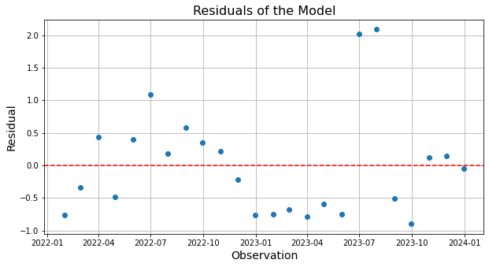

```python
predictions = model.predict(X)

# Calculate the residuals
residuals = y - predictions

# Plotting residuals
plt.figure(figsize=(10, 5))
plt.plot(residuals, marker='o', linestyle='')
plt.title('Residuals of the Model', fontsize=16)
plt.xlabel('Observation', fontsize=14)
plt.ylabel('Residual', fontsize=14)
plt.axhline(y=0, color='r', linestyle='--')
plt.grid(True)
plt.show()
```

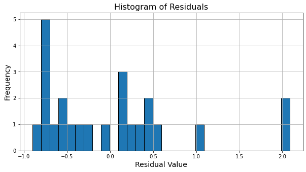

```python
# Histogram of the residuals
plt.figure(figsize=(10, 5))
plt.hist(residuals, bins=30, edgecolor='k')
plt.title('Histogram of Residuals', fontsize=16)
plt.xlabel('Residual Value', fontsize=14)
plt.ylabel('Frequency', fontsize=14)
plt.grid(True)
plt.show()
```

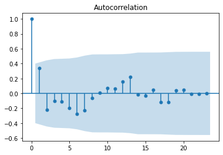

```python
import statsmodels.api as sm

n_obs = len(residuals)

# Set the number of lags to the minimum of 40 or n_obs-1
n_lags = min(40, n_obs - 1)

# Checking for autocorrelation of residuals with the appropriate number of lags
fig = sm.graphics.tsa.plot_acf(residuals, lags=n_lags)
plt.show()
```

```
d:\Programlar D\Anaconda\lib\site-packages\statsmodels\graphics\gofplots.py:993: UserWarning: marker is redundantly defined by the 'marker' keyword argument and the fmt string "bo" (-> marker='o'). The keyword argument will take precedence.
  ax.plot(x, y, fmt, **plot_style)
```

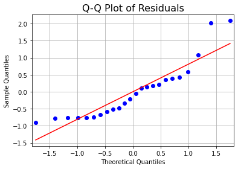

```python
import statsmodels.api as sm

# Checking for normality of residuals
sm.qqplot(residuals, line='s')
plt.title('Q-Q Plot of Residuals', fontsize=16)
plt.grid(True)
plt.show()
```

#### Analysis for the chosen model

R-squared: This model has a very high R-squared of 0.972, indicating that it explains 97.2% of the variance in the USD rate, which is quite high.

Adjusted R-squared: The adjusted R-squared is 0.959, which is also very high and suggests that the predictors have a significant explanatory power for the USD rate, even after adjusting for the number of predictors.

However, there might be overfitting in this case as R^2 is too high.

Residual Analysis:

Residual Plot: The residuals seem to be randomly scattered around the zero line, without any obvious patterns, which is good. However, there seems to be a couple of outliers that could potentially be influential points.

Q-Q Plot: Most of the points fall along the line, but there are deviations at the ends, suggesting that the residuals may have heavier tails than a normal distribution.

Significance of Coefficients:

Lag1 has a very significant t-statistic and a p-value of less than 0.001, making it a strong predictor.

The coefficients for Lag12, Lag1_keyword, Lag12_keyword, Lag3, Lag4, and Lag6 are not statistically significant at conventional levels (p > 0.05), with very high p-values indicating that they might not be useful predictors of the USD rate.

## Gold Production Time Series Analysis

#### Keyword data pre-process steps

```python
file_path = 'C:/Users/Kaan Ertan/Desktop/ie360-hw1/gold_prod.csv'

gold_prod = pd.read_csv(file_path)
```

```python
gold_prod
```

|  | Kategori: Tüm kategoriler |
| --- | --- |
| Hafta | altın yatırım: (Türkiye) |
| 2020-12-27 | 63 |
| 2021-01-03 | 68 |
| 2021-01-10 | 58 |
| 2021-01-17 | 49 |
| ... | ... |
| 2023-12-03 | 59 |
| 2023-12-10 | 56 |
| 2023-12-17 | 70 |
| 2023-12-24 | 66 |
| 2023-12-31 | 55 |

159 rows × 1 columns

```python
gold_prod.reset_index(inplace=True)
print("Columns in the DataFrame: ", gold_prod.columns.tolist())
```

```
Columns in the DataFrame:  ['index', 'Kategori: Tüm kategoriler']
```

```python
gold_prod.rename(columns={'index': 'Hafta'}, inplace=True)
gold_prod = gold_prod.iloc[1:]
gold_prod['Hafta'] = pd.to_datetime(gold_prod['Hafta'])
```

```python
gold_prod.set_index('Hafta', inplace=True)

# Group by month and aggregate the weekly data. Choose the aggregation method: sum, mean, etc.
gold_prod_monthly = gold_prod.resample('M').sum()
```

```python
gold_prod_monthly.rename(columns={'Kategori: Tüm kategoriler': 'monthly_keyword'}, inplace=True)

gold_prod_monthly
```

| Hafta | monthly_keyword |
| --- | --- |
| 2020-12-31 | 63 |
| 2021-01-31 | 6858495373 |
| 2021-02-28 | 65746664 |
| 2021-03-31 | 44446657 |
| 2021-04-30 | 32375334 |
| 2021-05-31 | 3737464048 |
| 2021-06-30 | 34482939 |
| 2021-07-31 | 26272329 |
| 2021-08-31 | 3938393342 |
| 2021-09-30 | 31404736 |
| 2021-10-31 | 3645354838 |
| 2021-11-30 | 72838879 |
| 2021-12-31 | 641008261 |
| 2022-01-31 | 5129403940 |
| 2022-02-28 | 40535545 |
| 2022-03-31 | 51463648 |
| 2022-04-30 | 45454752 |
| 2022-05-31 | 4758444639 |
| 2022-06-30 | 53453844 |
| 2022-07-31 | 4143545153 |
| 2022-08-31 | 60584455 |
| 2022-09-30 | 57525045 |
| 2022-10-31 | 4856504146 |
| 2022-11-30 | 51654862 |
| 2022-12-31 | 64657267 |
| 2023-01-31 | 6881736161 |
| 2023-02-28 | 38414753 |
| 2023-03-31 | 56667059 |
| 2023-04-30 | 7366777870 |
| 2023-05-31 | 74575959 |
| 2023-06-30 | 70535752 |
| 2023-07-31 | 6164937169 |
| 2023-08-31 | 67776361 |
| 2023-09-30 | 61565656 |
| 2023-10-31 | 6450745558 |
| 2023-11-30 | 39514669 |
| 2023-12-31 | 5956706655 |

```python
gold_production.index = gold_production.index.to_period('M').to_timestamp('M')
gold_prod_monthly.index = gold_prod_monthly.index.to_period('M').to_timestamp('M')
combined_data3 = gold_production.join(gold_prod_monthly, how='inner')
```

#### Time series

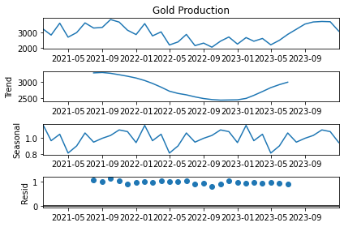

```python
import pandas as pd
import numpy as np
from statsmodels.tsa.seasonal import seasonal_decompose
from statsmodels.tsa.statespace.sarimax import SARIMAX
import matplotlib.pyplot as plt


# Decompose the time series into trend, seasonal, and residual components
decomposition = seasonal_decompose(combined_data3['Gold Production'], model='multiplicative', period=12)

# Plot the decomposed components
decomposition.plot()
plt.show()
```

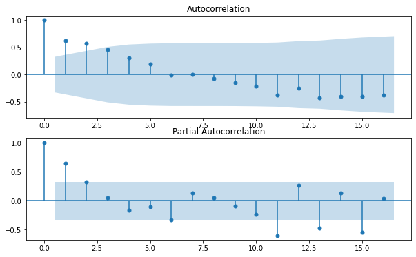

```python
import pandas as pd
import numpy as np
import matplotlib.pyplot as plt
from statsmodels.graphics.tsaplots import plot_acf, plot_pacf
fig, ax = plt.subplots(2, 1, figsize=(10, 6))
plot_acf(combined_data3['Gold Production'], ax=ax[0])
plot_pacf(combined_data3['Gold Production'], ax=ax[1])
plt.show()
```

```python
combined_data3
```

|  | Gold Production | monthly_keyword |
| --- | --- | --- |
| 2021-01-31 | 3232.106 | 6858495373 |
| 2021-02-28 | 2850.799 | 65746664 |
| 2021-03-31 | 3629.997 | 44446657 |
| 2021-04-30 | 2713.107 | 32375334 |
| 2021-05-31 | 3013.055 | 3737464048 |
| 2021-06-30 | 3647.311 | 34482939 |
| 2021-07-31 | 3310.844 | 26272329 |
| 2021-08-31 | 3350.437 | 3938393342 |
| 2021-09-30 | 3866.106 | 31404736 |
| 2021-10-31 | 3699.891 | 3645354838 |
| 2021-11-30 | 3168.756 | 72838879 |
| 2021-12-31 | 2883.069 | 641008261 |
| 2022-01-31 | 3600.302 | 5129403940 |
| 2022-02-28 | 2797.71 | 40535545 |
| 2022-03-31 | 3058.331 | 51463648 |
| 2022-04-30 | 2203.244 | 45454752 |
| 2022-05-31 | 2401.562 | 4758444639 |
| 2022-06-30 | 2893.962 | 53453844 |
| 2022-07-31 | 2159.961 | 4143545153 |
| 2022-08-31 | 2324.767 | 60584455 |
| 2022-09-30 | 2058.017 | 57525045 |
| 2022-10-31 | 2452.144 | 4856504146 |
| 2022-11-30 | 2724.423 | 51654862 |
| 2022-12-31 | 2259.987 | 64657267 |
| 2023-01-31 | 2686.612 | 6881736161 |
| 2023-02-28 | 2447.854 | 38414753 |
| 2023-03-31 | 2628.564 | 56667059 |
| 2023-04-30 | 2213.008 | 7366777870 |
| 2023-05-31 | 2508.55 | 74575959 |
| 2023-06-30 | 2894.89 | 70535752 |
| 2023-07-31 | 3230.953 | 6164937169 |
| 2023-08-31 | 3569.637 | 67776361 |
| 2023-09-30 | 3707.483 | 61565656 |
| 2023-10-31 | 3740.1 | 6450745558 |
| 2023-11-30 | 3724.129 | 39514669 |
| 2023-12-31 | 3103.036 | 5956706655 |

#### Model with identified lags

```python
import pandas as pd
from statsmodels.tsa.stattools import adfuller
from statsmodels.regression.linear_model import OLS
from statsmodels.tools import add_constant

combined_data3['Lag1'] = combined_data3['Gold Production'].shift(1)
combined_data3['Lag2'] = combined_data3['Gold Production'].shift(2)
combined_data3['Lag3'] = combined_data3['Gold Production'].shift(3)
combined_data3['Lag4'] = combined_data3['Gold Production'].shift(4)

combined_data3['Lag6'] = combined_data3['Gold Production'].shift(6)  # This is a yearly lag, adjust according to your data frequency


combined_data3['Lag1_keyword'] = combined_data3['monthly_keyword'].shift(1)
combined_data3['Lag6_keyword'] = combined_data3['monthly_keyword'].shift(6)  # This is a yearly lag, adjust according to your data frequency

combined_data3.dropna(inplace=True)
```

```python
combined_data3['Gold Production'] = pd.to_numeric(combined_data3['Gold Production'], errors='coerce')
combined_data3['Lag1'] = pd.to_numeric(combined_data3['Lag1'], errors='coerce')
combined_data3['Lag2'] = pd.to_numeric(combined_data3['Lag2'], errors='coerce')
combined_data3['Lag3'] = pd.to_numeric(combined_data3['Lag3'], errors='coerce')
combined_data3['Lag4'] = pd.to_numeric(combined_data3['Lag4'], errors='coerce')

combined_data3['Lag6'] = pd.to_numeric(combined_data3['Lag6'], errors='coerce')

combined_data3['Lag1_keyword'] = pd.to_numeric(combined_data3['Lag1_keyword'], errors='coerce')
combined_data3['Lag6_keyword'] = pd.to_numeric(combined_data3['Lag6_keyword'], errors='coerce')
```

```python
X = combined_data3[['Lag1', 'Lag2','Lag1_keyword','Lag6_keyword','Lag3','Lag4','Lag6']]
y = combined_data3['Gold Production']

# Add a constant to the model (the intercept term)
X = add_constant(X)

# Fit the model
model = OLS(y, X).fit()

# Output the summary of the model
print(model.summary())
```

```
                            OLS Regression Results
==============================================================================
Dep. Variable:        Gold Production   R-squared:                       0.615
Model:                            OLS   Adj. R-squared:                  0.493
Method:                 Least Squares   F-statistic:                     5.025
Date:                Fri, 05 Apr 2024   Prob (F-statistic):            0.00161
Time:                        21:52:52   Log-Likelihood:                -217.54
No. Observations:                  30   AIC:                             451.1
Df Residuals:                      22   BIC:                             462.3
Df Model:                           7
Covariance Type:            nonrobust
================================================================================
                   coef    std err          t      P>|t|      [0.025      0.975]
--------------------------------------------------------------------------------
const         1135.2417    542.299      2.093      0.048      10.582    2259.901
Lag1             0.5276      0.218      2.420      0.024       0.076       0.980
Lag2             0.2820      0.225      1.252      0.224      -0.185       0.749
Lag1_keyword  1.615e-08   2.99e-08      0.541      0.594   -4.58e-08    7.81e-08
Lag6_keyword   -1.8e-08    3.4e-08     -0.530      0.602   -8.85e-08    5.25e-08
Lag3             0.0509      0.224      0.227      0.823      -0.414       0.516
Lag4             0.0435      0.201      0.216      0.831      -0.374       0.461
Lag6            -0.2999      0.178     -1.686      0.106      -0.669       0.069
==============================================================================
Omnibus:                        1.684   Durbin-Watson:                   1.913
Prob(Omnibus):                  0.431   Jarque-Bera (JB):                1.461
Skew:                           0.402   Prob(JB):                        0.482
Kurtosis:                       2.277   Cond. No.                     2.57e+10
==============================================================================

Notes:
[1] Standard Errors assume that the covariance matrix of the errors is correctly specified.
[2] The condition number is large, 2.57e+10. This might indicate that there are
strong multicollinearity or other numerical problems.
```

#### Residual analysis

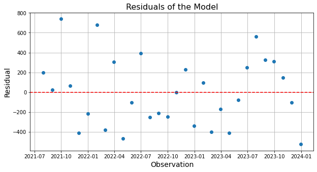

```python
predictions = model.predict(X)

# Calculate the residuals
residuals = y - predictions

# Plotting residuals
plt.figure(figsize=(10, 5))
plt.plot(residuals, marker='o', linestyle='')
plt.title('Residuals of the Model', fontsize=16)
plt.xlabel('Observation', fontsize=14)
plt.ylabel('Residual', fontsize=14)
plt.axhline(y=0, color='r', linestyle='--')
plt.grid(True)
plt.show()
```

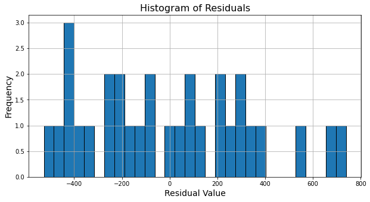

```python
# Histogram of the residuals
plt.figure(figsize=(10, 5))
plt.hist(residuals, bins=30, edgecolor='k')
plt.title('Histogram of Residuals', fontsize=16)
plt.xlabel('Residual Value', fontsize=14)
plt.ylabel('Frequency', fontsize=14)
plt.grid(True)
plt.show()
```

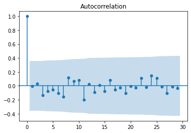

```python
import statsmodels.api as sm

n_obs = len(residuals)

# Set the number of lags to the minimum of 40 or n_obs-1
n_lags = min(40, n_obs - 1)

# Checking for autocorrelation of residuals with the appropriate number of lags
fig = sm.graphics.tsa.plot_acf(residuals, lags=n_lags)
plt.show()
```

```
d:\Programlar D\Anaconda\lib\site-packages\statsmodels\graphics\gofplots.py:993: UserWarning: marker is redundantly defined by the 'marker' keyword argument and the fmt string "bo" (-> marker='o'). The keyword argument will take precedence.
  ax.plot(x, y, fmt, **plot_style)
```

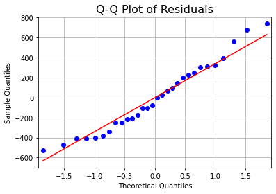

```python
import statsmodels.api as sm

# Checking for normality of residuals
sm.qqplot(residuals, line='s')
plt.title('Q-Q Plot of Residuals', fontsize=16)
plt.grid(True)
plt.show()
```

#### Analysis for the Chosen Model

R-squared: The model has an R-squared of 0.615, which means it explains 61.5% of the variability in gold production. This is a moderate fit.

Adjusted R-squared: The adjusted R-squared is 0.493, indicating that when the number of predictors is taken into account, the model explains about 49.3% of the variability in gold production.

Residual Analysis:

Residual Plot: The residuals don't show a clear pattern, which is good, but there are some outliers. The outliers can potentially have a high leverage and can affect the regression line.

Histogram of Residuals: The histogram shows that the residuals might not be normally distributed; there is a slight skew towards the right. A normally distributed histogram of residuals is an assumption of the OLS regression.

Autocorrelation: The autocorrelation plot suggests that there is little to no autocorrelation among the residuals, as the dots are mostly within the confidence interval and there are no clear patterns. This is a good sign and is supported by the Durbin-Watson statistic of 1.913, which is close to the value of 2 that indicates no autocorrelation.

Q-Q Plot: There are deviations from the line, especially at the tails, indicating that the residuals might not be normally distributed, which can be an issue for the assumptions of OLS regression.

Significance of Coefficients:

The constant and Lag1 are statistically significant (p < 0.05), suggesting that they are important predictors of gold production.

Lag2, Lag1_keyword, Lag6_keyword, Lag3, Lag4, and Lag6 have p-values greater than 0.05, indicating that they are not statistically significant at the conventional level.